# ISA 365 Output Packet Version A

Last complied on May 12, 2025

## Walmart Test

Walmart ran this larger A/B test on their product detail pages which leaped them from a 2 column to a 3 column layout. The evolution seems inline with a similar finding that Amazon discovered a few years back (with an inverse setup). The A/B test contained at least the following 5 changes changes (shown in version B):

1. Centered Headline
2. Visible Product Descriptions
3. Bullet Product Descriptions
4. Multiple Buy Box (Right Column) Changes
5. Product Thumbnail Photos

[figure not shown]

Walmart A

[figure not shown]

Walmart B

### Frist Test: Sales per User

The first test was done on the sales per user. The analysis is below.

```r
head(df)
```

```
##   test spend
## 1    A 33.81
## 2    A 21.30
## 3    A 52.13
## 4    A 28.31
## 5    A 42.64
## 6    A 31.73
```

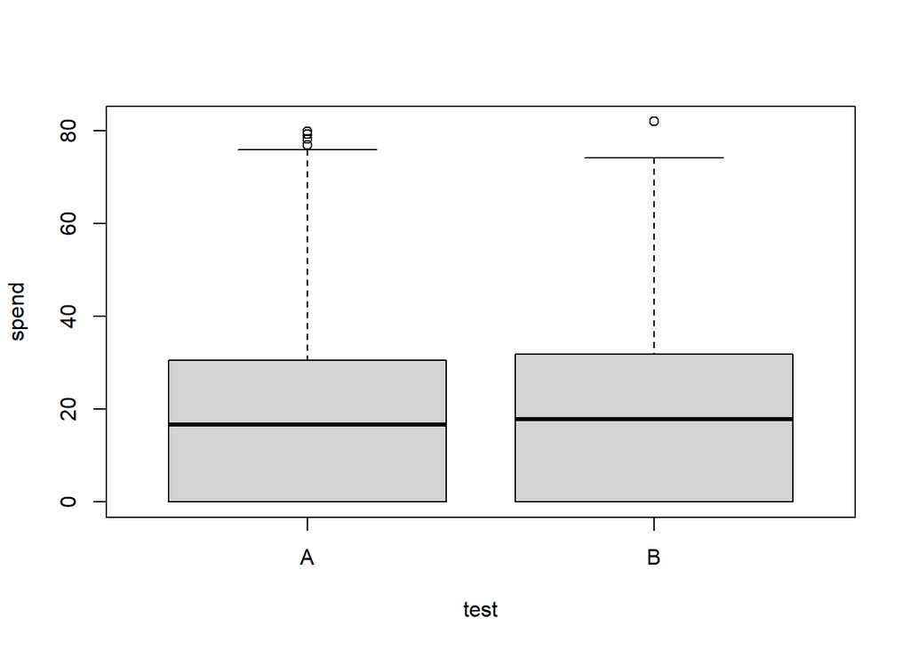

```r
boxplot(spend~test, data=df)
```

```r
t.test(spend~test, data=df)
```

```
##
##  Welch Two Sample t-test
##
## data:  spend by test
## t = -3.087, df = 25518, p-value = 0.002024
## alternative hypothesis: true difference in means between group A and group B is not equal to 0
## 95 percent confidence interval:
##  -1.0735104 -0.2397069
## sample estimates:
## mean in group A mean in group B
##        17.71779        18.37440
```

### Second Test: Purchase Rate

Another data scientist at Walmart decided that it would be better to test the purchase rate (purchase or not) than the spend.

```r
df$purchase<-ifelse(df$spend>0, 1, 0)
head(df)
```

```
##   test spend purchase
## 1    A 33.81        1
## 2    A 21.30        1
## 3    A 52.13        1
## 4    A 28.31        1
## 5    A 42.64        1
## 6    A 31.73        1
```

```
## # A tibble: 4 × 4
## # Groups:   purchase [2]
##   purchase test      n  freq
##      <dbl> <chr> <int> <dbl>
## 1        0 A      4757 0.513
## 2        0 B      4513 0.487
## 3        1 A      8244 0.506
## 4        1 B      8047 0.494
```

```r
set.seed(13)
iter=100000
a=8244+1
b=4757+1
a1=8047+1
b1=4513+1
count<-c()
for (i in 1:iter){
A<-rbeta(1, a, b)
B<-rbeta(1, a1, b1)
count[i]<-ifelse(A>B, 1, 0)


}
pdiff<-sum(count)/iter
pdiff
```

```
## [1] 0.1365
```

#### Individual confidence intervals for version B:

```r
prop.test(x=c(8047), n=c( 4513+8047))
```

```
##
##  1-sample proportions test with continuity correction
##
## data:  c(8047) out of c(4513 + 8047), null probability 0.5
## X-squared = 993.8, df = 1, p-value < 2.2e-16
## alternative hypothesis: true p is not equal to 0.5
## 95 percent confidence interval:
##  0.6322119 0.6490711
## sample estimates:
##         p
## 0.6406847
```

```r
a1=8047+1
b1=4513+1
qbeta(0.975, a1, b1)
```

```
## [1] 0.649031
```

```r
qbeta(0.025, a1, b1)
```

```
## [1] 0.6322512
```

## Anheuser-Busch

The Anheuser-Busch beer company wanted to determine how much money to spend on advertising. They tested the following: (i) 50% increase, (ii) no change and (iii) 25% decrease in advertising expenditure over a 3 month period. They studied the changes in three different markets. They wished to make a general conclusion about the advertising expenditure, regardless of the market. They assumed the sales were not affected by the month over this time period. They measured the total sales.

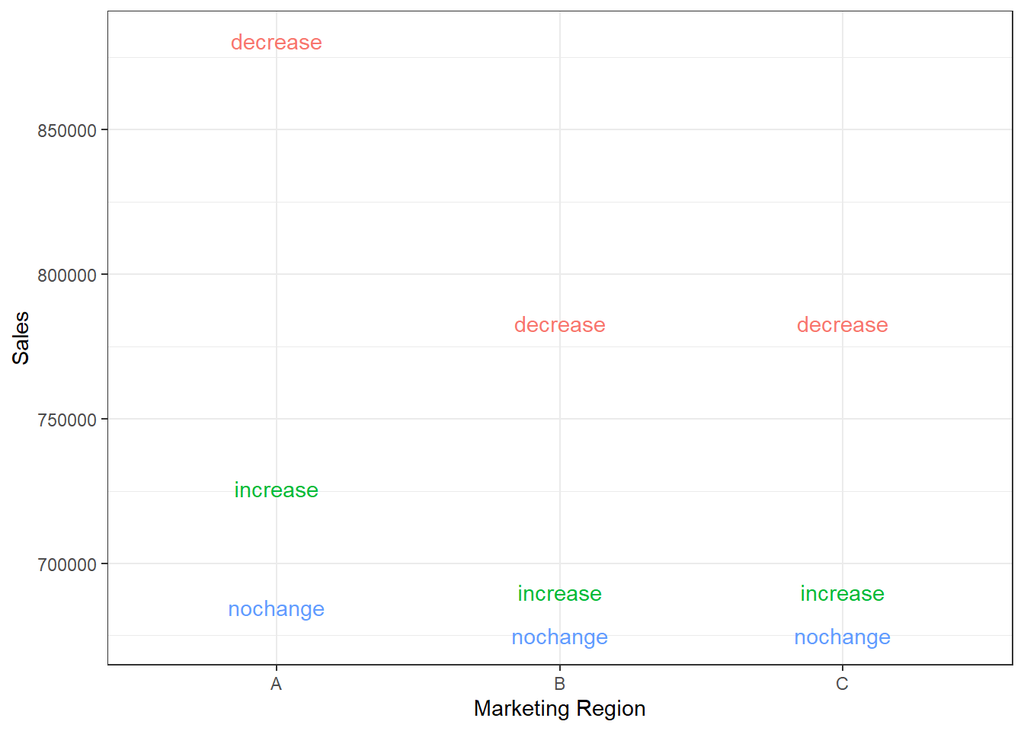

### Analysis

```
##             Df    Sum Sq   Mean Sq F value Pr(>F)
## treatment    2 3.233e+10 1.617e+10   13.33 0.0062 **
## Residuals    6 7.279e+09 1.213e+09
## ---
## Signif. codes:  0 '***' 0.001 '**' 0.01 '*' 0.05 '.' 0.1 ' ' 1
```

```
##             Df    Sum Sq   Mean Sq F value  Pr(>F)
## treatment    2 3.233e+10 1.617e+10  23.850 0.00599 **
## marketing    2 4.567e+09 2.284e+09   3.369 0.13877
## Residuals    4 2.711e+09 6.778e+08
## ---
## Signif. codes:  0 '***' 0.001 '**' 0.01 '*' 0.05 '.' 0.1 ' ' 1
```

## Retail Experiment

A retail company is testing the impact of three factors on sales performance. Each factor has two levels:

**Factor A (Pricing Strategy)**: Low level: Regular pricing (no discount). High level: 20% discount.

**Factor B (Advertising Channel)**: Low level: Social media ads only. High level: Social media + email campaign.

**Factor C (Store Layout)**: Low level: Traditional layout. High level: Modern layout with improved navigation.

| A | B | C | y |
| --- | --- | --- | --- |
| 1 | 1 | 1 | 1888.92 |
| -1 | 1 | -1 | 1952.50 |
| -1 | -1 | 1 | 1387.50 |
| 1 | -1 | -1 | 1959.80 |
| -1 | -1 | -1 | 1388.47 |
| 1 | -1 | 1 | 1972.04 |
| -1 | 1 | 1 | 1936.77 |
| 1 | 1 | -1 | 1916.06 |

### Analysis Step 1

```r
reg<-lm(y~A*B*C, data=df)
summary(reg)
```

```
##
## Call:
## lm.default(formula = y ~ A * B * C, data = df)
##
## Residuals:
## ALL 8 residuals are 0: no residual degrees of freedom!
##
## Coefficients:
##             Estimate Std. Error t value Pr(>|t|)
## (Intercept) 1800.257        NaN     NaN      NaN
## A            133.947        NaN     NaN      NaN
## B            123.305        NaN     NaN      NaN
## C             -3.950        NaN     NaN      NaN
## A:B         -155.020        NaN     NaN      NaN
## A:C            0.225        NaN     NaN      NaN
## B:C           -6.768        NaN     NaN      NaN
## A:B:C         -3.078        NaN     NaN      NaN
##
## Residual standard error: NaN on 0 degrees of freedom
## Multiple R-squared:      1,  Adjusted R-squared:    NaN
## F-statistic:   NaN on 7 and 0 DF,  p-value: NA
```

### Analysis Step 2

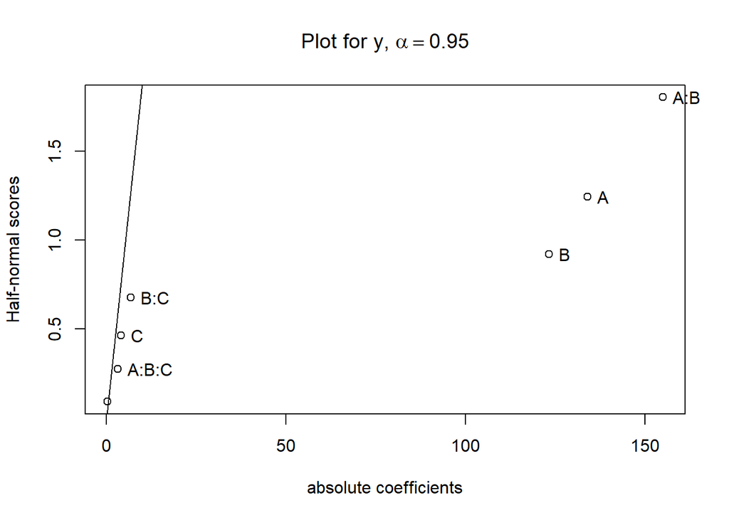

```r
library(DoE.base)

hncoeff<-halfnormal(reg, alpha=0.95)$coef
pse<-ME.Lenth(hncoeff)$PSE
abline(a=0, b=1/pse)
```

### Analysis Step 3

```r
reg<-lm(y~A*B*C-A:B:C, data=df)
summary(reg)
```

```
##
## Call:
## lm.default(formula = y ~ A * B * C - A:B:C, data = df)
##
## Residuals:
##      1      2      3      4      5      6      7      8
## -3.078 -3.078 -3.078 -3.078  3.078  3.078  3.078  3.078
##
## Coefficients:
##             Estimate Std. Error t value Pr(>|t|)
## (Intercept) 1800.257      3.078 584.974  0.00109 **
## A            133.947      3.078  43.525  0.01462 *
## B            123.305      3.078  40.067  0.01589 *
## C             -3.950      3.078  -1.284  0.42136
## A:B         -155.020      3.078 -50.372  0.01264 *
## A:C            0.225      3.078   0.073  0.95354
## B:C           -6.768      3.078  -2.199  0.27171
## ---
## Signif. codes:  0 '***' 0.001 '**' 0.01 '*' 0.05 '.' 0.1 ' ' 1
##
## Residual standard error: 8.704 on 1 degrees of freedom
## Multiple R-squared:  0.9998, Adjusted R-squared:  0.9988
## F-statistic:  1007 on 6 and 1 DF,  p-value: 0.02411
```

### Assumptions Plot 1

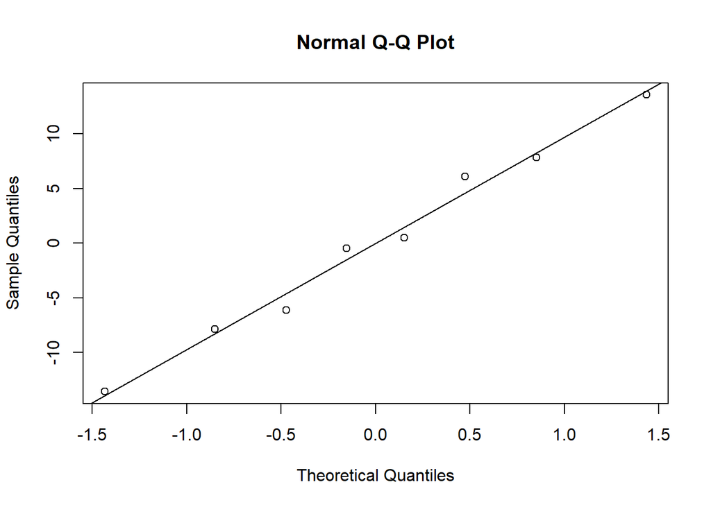

```r
qqnorm(reg$residuals)
qqline(reg$residuals)
```

### Assumptions Plot 2

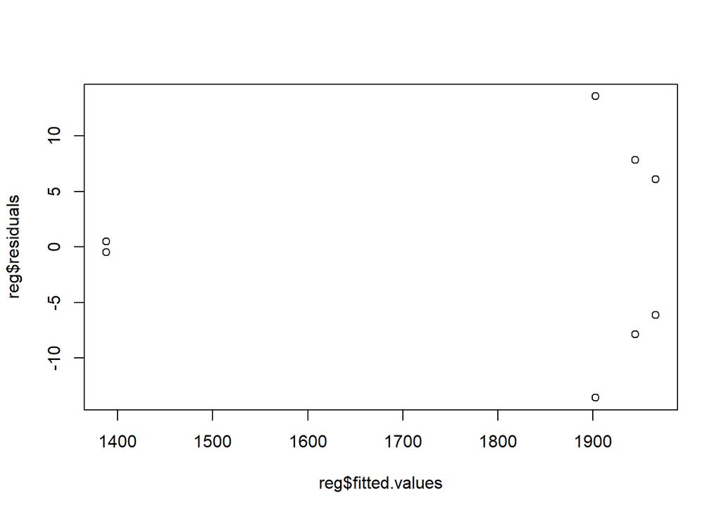

```r
plot(reg$fitted.values, reg$residuals )
```

### Assumptions Plot 3

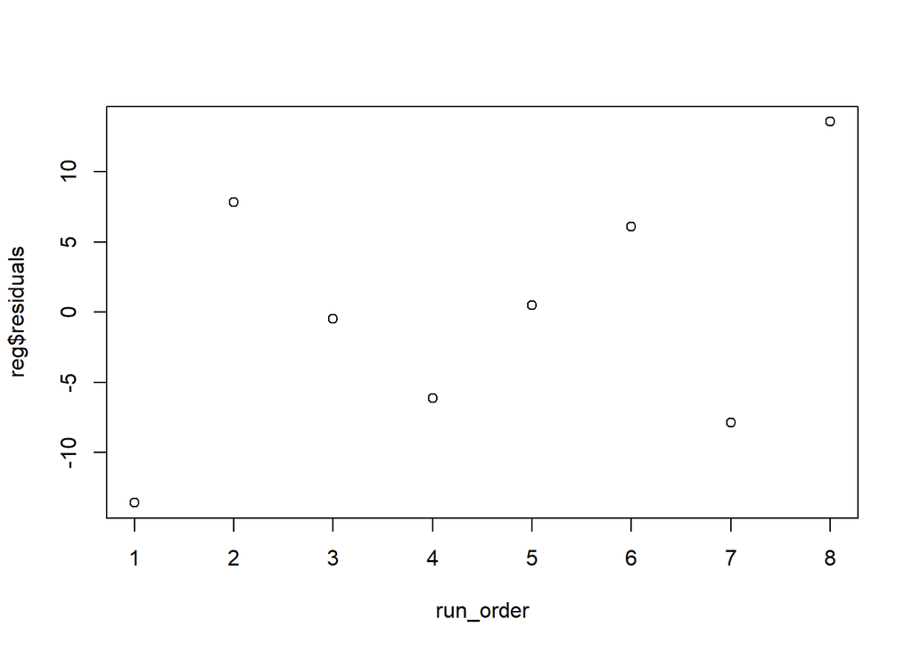

```r
plot(run_order, reg$residuals)
```

### Plots

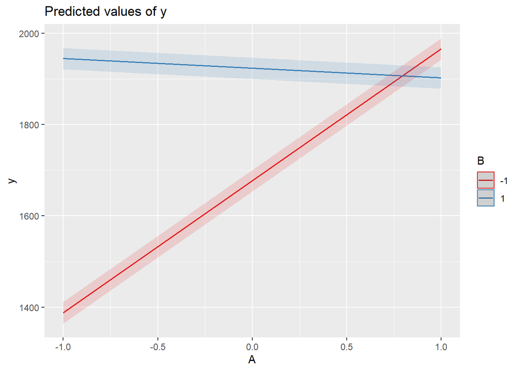

```r
library(sjPlot)
plot_model(reg, type="int")
```

## Comcast Customer Service

```r
library(qcc)
q<-qcc(df, type="R")
```

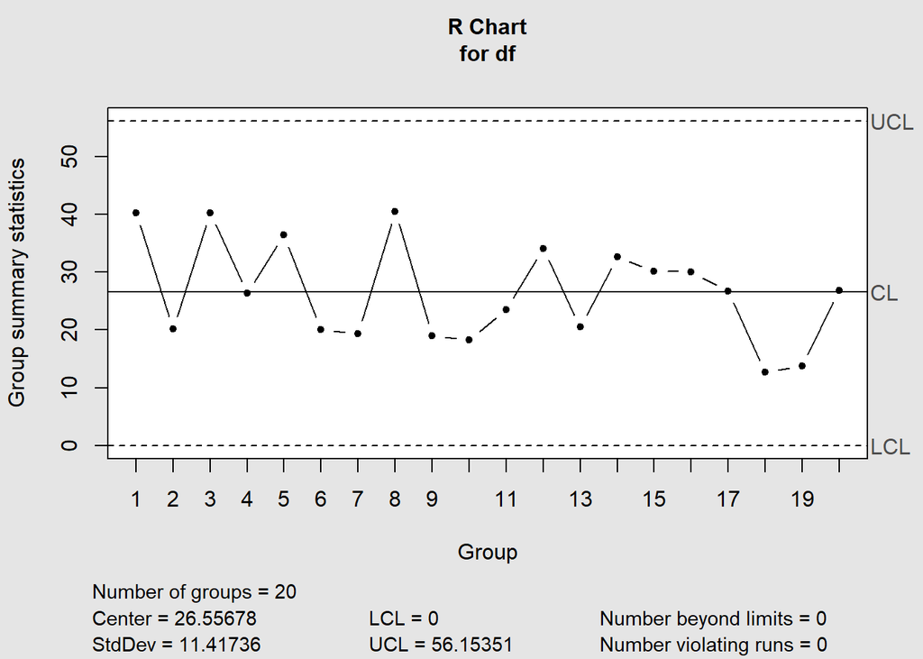

```r
q<-qcc(df, type="xbar")
```

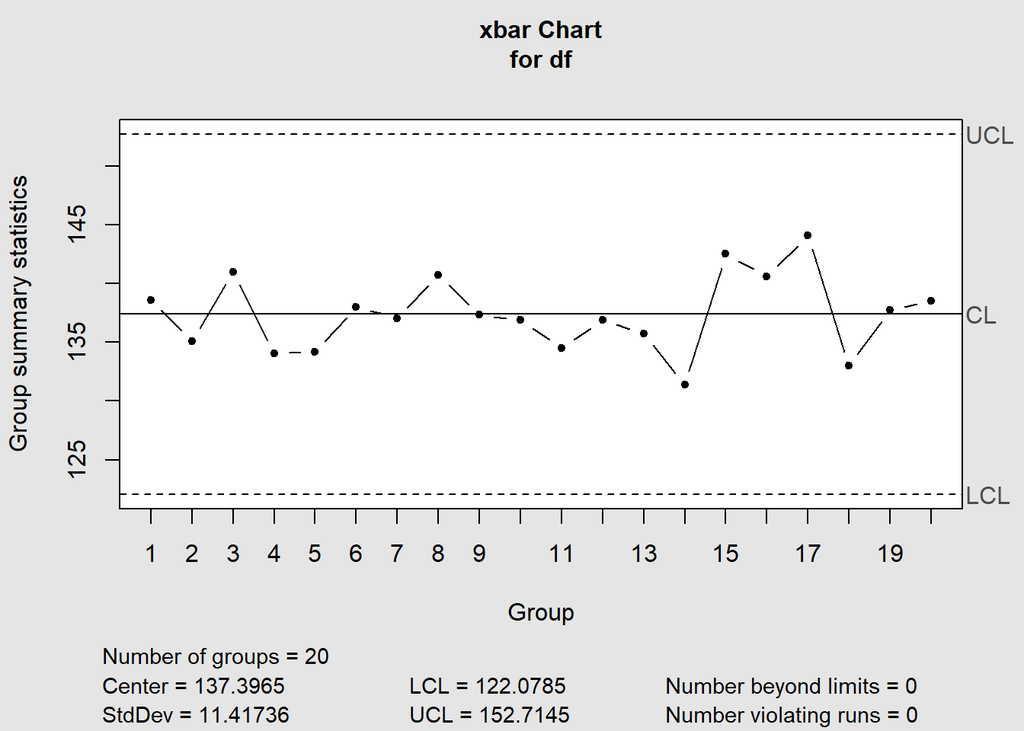